# RMarkdown_Ed1

## Results

Functions read-in from R Script file:

EdGraph1 & EdGraph2 - Both of these graphs utilize the same setup - the only difference is between the outputs “Number of Injuries” and “Number of People Killed”. These graphs both use the same data set that describes some of the details of all shootings in America that classify as a “mass shooting” - four or more people being injured. We then use the data set to split the dates into Quarter years to make a less cluttered and clearer appearance for the graph. We then made a couple of times series so that we could make a dataset only containing the dates (quarters) along with either the number of people killed or the number of people injured. We then have to define in R each quarter and which months each of them represent.

EdGraph1 - This function graphs the number of injuries caused by mass shootings (per quarter/year).

EdGraph2 - This function graphs the number of people killed in a mass shooting (per quarter/year).

EdGraph - This function combines the functions EdGraph1 and EdGraph 2 and forms an if-then statement. The function will print out EdGraph1() if either EdGraph(1) or EdGraph(“Injured”) are entered. If any other numbers or words are selected after EdGraph(), then EdGraph2() will automatically plot instead of EdGraph1().

The functions we defined can be used in the following ways:

### Example 1

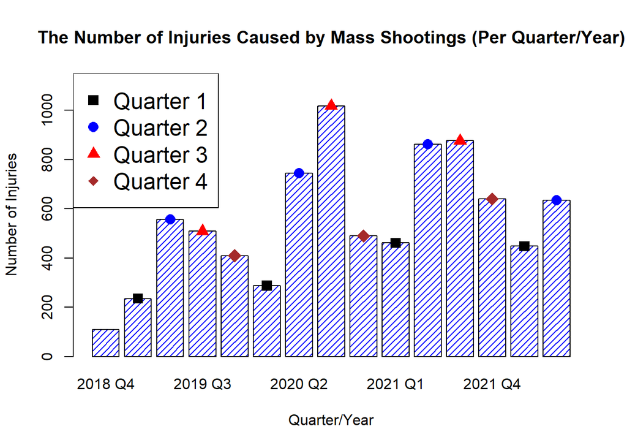

```r
library(dplyr)
library(tidyverse)
EdGraph(1)
```

### Example 2

```r
EdGraph(2)
```

[output not shown]

### Example 3

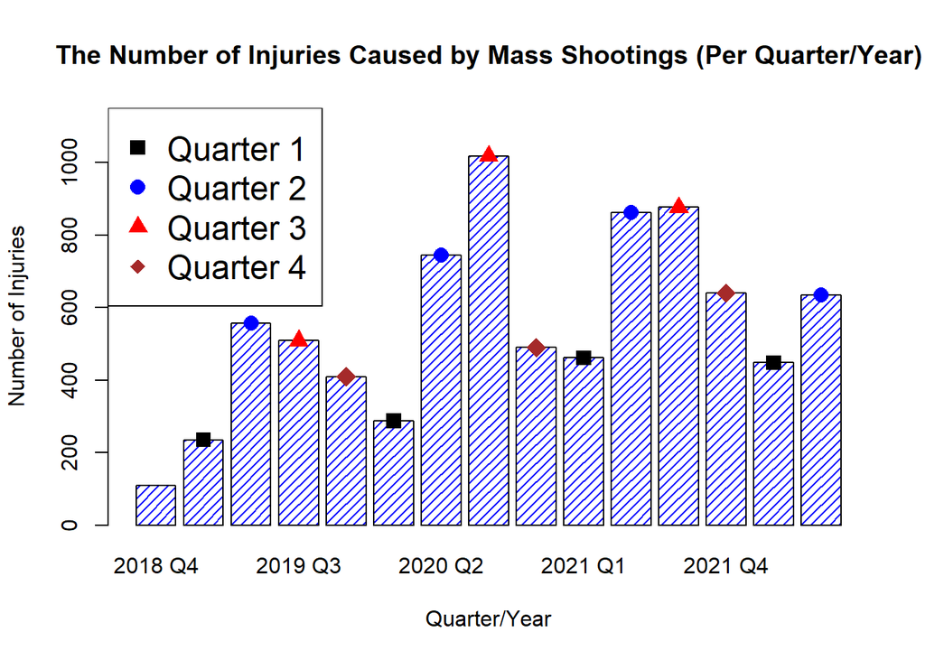

```r
EdGraph("Injured")
```

Using the “If” statement from the R Script File sourced into this R Markdown, we are able to tell R to switch between two different graphs - one defining the number of injuries due to mass shootings quarterly in the U.S. and one defining the number of fatalities due to mass shootings quarterly in the United States. R can tell which graph to display by using the EdGraph() function and typing a number or name in place of the x input. If the x-input says “Injured” or the number “1”, R will automatically display the graph with the number of injuries. Since here, “Injured” is put in place of x input, the number of injuries are shown quarterly.

### Example 4

```r
EdGraph("Killed")
```

[output not shown]

### Example 5

```r
EdGraph("Fatalities")
```

[output not shown]

### Example 6

```r
EdGraph("Anything here")
```

[output not shown]